# South Africa’s Monetary Policy Committee Statement (Jan 2024) - Bigram Analysis

Kudzanai Tsunga

2024-02-06

## South Africa’s Monetary Policy Committee Statement (Jan 2024) - Bigram Analysis

This a summary of the South African Reserve Bank’s Monetary Policy Committee (MPC) statement using bigrams. The statement is avialable from: https://www.resbank.co.za/en/home/publications/statements/mpc-statements

## Summary of MPC Statement

The statement highlights that global economic conditions are uncertain despite easing headline inflation. In addition, it notes that advanced and emerging economies anticipate modest growth, prioritizing inflation targets, fiscal deficits, and debt reduction. Geo-political tensions and climate change add to the uncertainty, impacting supply chains and prices. South Africa’s GDP growth is sluggish due to port, rail, and electricity constraints. Despite some improvements, inflation risks persist, especially regarding fuel and food prices. Global financial conditions are tight, raising risks for economies needing foreign capital like South Africa. Inflation expectations remain high, prompting the MPC to maintain a restrictive policy stance.The Committee recommends strengthening economic conditions by managing debt, enhancing energy supply, and maintaining stable wage growth. Monetary policy effectiveness is crucial for broader economic stability amidst ongoing uncertainties

## Bigram Analysis of the MPC Statement

A bigram network analysis enables us to elucidate the key details of the monetary policy statement.

```r
# loading libraries
library(tidytext)
library(janeaustenr)
library(readr)
library(dplyr)
# loading the monetary policy statement text file, setting a two-word bigram and and removing stopwords
text <- read_csv("mpc_25012024.csv")
mpc_bigrams <- text %>%
  unnest_tokens(bigram, notes, token = "ngrams", n = 2)

# cleaning the text file to remove the for stop words

library(tidyr)
bigrams_separated <- mpc_bigrams %>%
  separate(bigram, c("word1", "word2"), sep = " ")

bigrams_filtered <- bigrams_separated %>%
  filter(!word1 %in% stop_words$word) %>%
    filter(!word2 %in% stop_words$word)
```

After removing the stopwords, the new MPC bigrams are now as follows:

```r
bigram_counts <- bigrams_filtered %>%
  count(word1, word2, sort = TRUE)

bigram_counts
```

```
## # A tibble: 281 × 3
##    word1     word2            n
##    <chr>     <chr>        <int>
##  1 price     inflation        6
##  2 inflation expectations     5
##  3 south     africa           5
##  4 core      inflation        4
##  5 headline  inflation        4
##  6 commodity export           3
##  7 economic  outlook          3
##  8 export    prices           3
##  9 food      price            3
## 10 inflation remains          3
## # ℹ 271 more rows
```

Using tidyr’s unite() function whic is the opposite of separate() combines the word1 and word2 columns into one. In other analyses, working with recombined words is better; the one-bigram-per-row format is helpful for exploratory analyses of the text.

From the bigrams above, it was evident that inflation was common in the top 5 bigrams. The following unites the bigrams and filters for “inflation”

```r
bigrams_united <- bigrams_filtered %>%
  unite(bigram, word1, word2, sep = " ")

bigrams_united
```

```
## # A tibble: 332 × 2
##    admin1      bigram
##    <chr>       <chr>
##  1 mpc_jan2024 begins global
##  2 mpc_jan2024 global economic
##  3 mpc_jan2024 economic conditions
##  4 mpc_jan2024 conditions remain
##  5 mpc_jan2024 remain mixed
##  6 mpc_jan2024 outlook uncertain
##  7 mpc_jan2024 headline inflation
##  8 mpc_jan2024 inflation continues
##  9 mpc_jan2024 world core
## 10 mpc_jan2024 core inflation
## # ℹ 322 more rows
```

```r
bigrams_filtered %>%
  filter(word1 == "inflation") %>%
  count(word1, word2, sort = TRUE)
```

```
## # A tibble: 15 × 3
##    word1     word2            n
##    <chr>     <chr>        <int>
##  1 inflation expectations     5
##  2 inflation remains          3
##  3 inflation forecast         2
##  4 inflation rate             2
##  5 inflation continues        1
##  6 inflation increased        1
##  7 inflation low              1
##  8 inflation outlook          1
##  9 inflation remain           1
## 10 inflation remaining        1
## 11 inflation risk             1
## 12 inflation risks            1
## 13 inflation south            1
## 14 inflation targets          1
## 15 inflation trajectory       1
```

Text analysis on bigrams within the dataset bigrams_united, computes their TF-IDF scores within each administrative region, and then arranges them in descending order based on their importance.

```r
bigram_tf_idf <- bigrams_united %>%
  count(admin1, bigram) %>%
  bind_tf_idf(bigram, admin1, n) %>%
  arrange(desc(tf_idf))

bigram_tf_idf
```

```
## # A tibble: 281 × 6
##    admin1      bigram             n      tf   idf tf_idf
##    <chr>       <chr>          <int>   <dbl> <dbl>  <dbl>
##  1 mpc_jan2024 1.1 average        1 0.00301     0      0
##  2 mpc_jan2024 1.3 rising         1 0.00301     0      0
##  3 mpc_jan2024 2022 reducing      1 0.00301     0      0
##  4 mpc_jan2024 2023 medium        1 0.00301     0      0
##  5 mpc_jan2024 2024 achieving     1 0.00301     0      0
##  6 mpc_jan2024 2024 compared      1 0.00301     0      0
##  7 mpc_jan2024 2024 food          1 0.00301     0      0
##  8 mpc_jan2024 2024 services      1 0.00301     0      0
##  9 mpc_jan2024 2026 services      1 0.00301     0      0
## 10 mpc_jan2024 4.8 core           1 0.00301     0      0
## # ℹ 271 more rows
```

Visualising the bigram analysis on an a graph using `igraph` begins with setting the minimum number of combinations to 2 (n = 2) [or as required]:

```r
## Visualizing a network of bigrams with ggraph

library(igraph)
bigram_graph <- bigram_counts %>%
  filter(n >= 2) %>%
    graph_from_data_frame()

bigram_graph
```

```
## IGRAPH c4b40ef DN-- 43 32 --
## + attr: name (v/c), n (e/n)
## + edges from c4b40ef (vertex names):
##  [1] price    ->inflation    inflation->expectations south    ->africa
##  [4] core     ->inflation    headline ->inflation    commodity->export
##  [7] economic ->outlook      export   ->prices       food     ->price
## [10] inflation->remains      advanced ->economies    average  ->salaries
## [13] economic ->conditions   economic ->growth       forecast ->period
## [16] gdp      ->growth       gdp      ->outcome      geo      ->political
## [19] global   ->growth       growth   ->forecast     inflation->forecast
## [22] inflation->rate         medium   ->term         modest   ->economic
## + ... omitted several edges
```

Plotting the bigram graph using `ggraph`

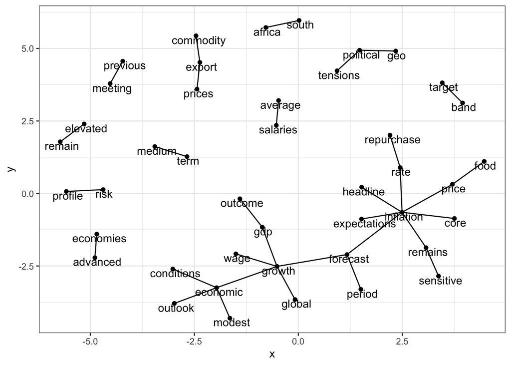

```r
library(ggraph)
set.seed(2017)

ggraph(bigram_graph, layout = "fr") +
  geom_edge_link() +
  geom_node_point() + theme_bw() +
  geom_node_text(aes(label = name), vjust = 1, hjust = 0.45)
```

In line with the `bigram_counts` from above, the word relationships from the `ggraph` shows inflation being the main centre node. additionally, economic growth was a commoth theme of the staement.

While the network showed the links and centre nodes of the MPC statement, additional information about the direction of relationship and the number of times the bigrams were counted aids the analysis.

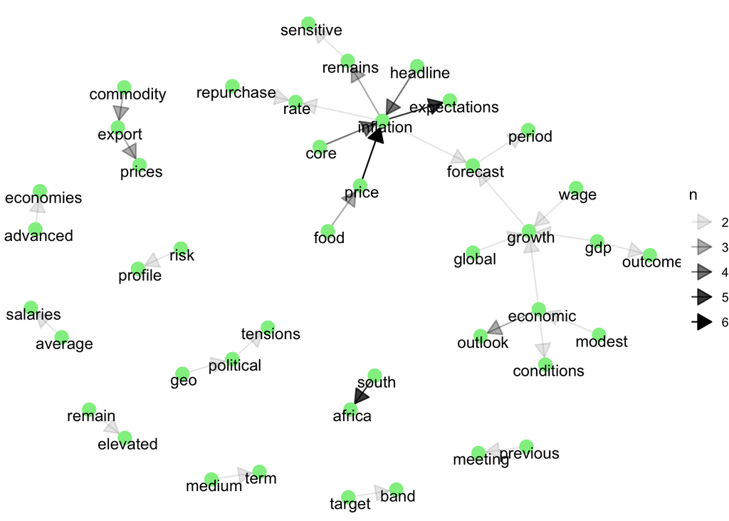

```r
set.seed(2020)

a <- grid::arrow(type = "closed", length = unit(.15, "inches"))

ggraph(bigram_graph, layout = "fr") +
  geom_edge_link(aes(edge_alpha = n), show.legend = TRUE,
                 arrow = a, end_cap = circle(.07, 'inches')) +
  geom_node_point(color = "lightgreen", size = 4) +
  geom_node_text(aes(label = name), vjust = 1, hjust = 0.45) +
  theme_void()
```

As already established, inflation was the central theme its outlooked remained sensitive: “price inflation” was mentioned 6 times and “inflation expectations” five times. This suggested that forecasted inflation remained a concern for the MPC and this was compounded by global economic uncertainty. The bigram shows that the food inflation and wage growth were concern and inform the MPC to maintain a restrictive policy stance by keeping interest rates elevated.

A quick `wordcloud` plot of the MPC statement complements the bigram.

```r
#install libraries
library("tm") #load library
```

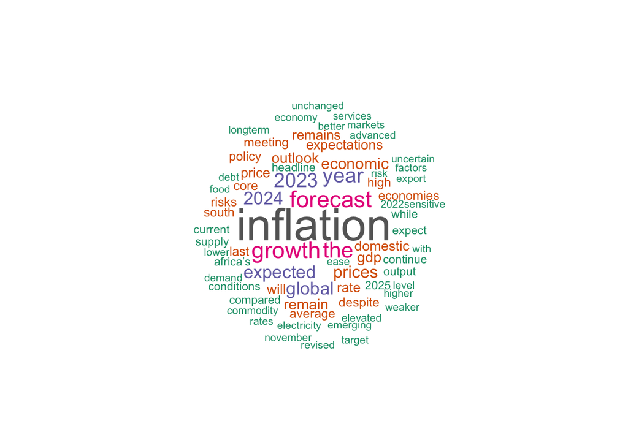

```r
library("SnowballC") #load library
library("wordcloud") #load library
library("RColorBrewer") #load library
library(readr)

text_data <- read_lines("mpc_25012024")
  docs <- Corpus(VectorSource(text_data))
    docs <- tm_map(docs, removeWords, stopwords("english"))
      docs <- tm_map(docs, removePunctuation)
#create the document matrix (table containing the word frequency)
dtm <- TermDocumentMatrix(docs)
    m <- as.matrix(dtm)
    v <- sort(rowSums(m),decreasing = TRUE)
    d <- data.frame(word = names(v),freq = v)

set.seed(1234)
wordcloud(words = d$word, freq = d$freq, min.freq = 3,
          max.words = 100, random.order = FALSE, rot.per = -0.5,
          colors = brewer.pal(8, "Dark2"),
          scale = c(3, 0.5))
```

### References

Julia Silge & David Robinson (2024). “Text Mining with R: A Tidy Approach”. Available from: https://www.tidytextmining.com/ngrams